# MSBA2_germcred_ElaYenikoylu

Captain Jack Sparrow

12/14/2020

```
## # A tibble: 20 x 5
##    checking duration history purpose amount
##       <dbl>    <dbl>   <dbl> <chr>    <dbl>
##  1        1        6       4 3         1169
##  2        2       48       2 3         5951
##  3        4       12       4 6         2096
##  4        1       42       2 2         7882
##  5        1       24       3 0         4870
##  6        4       36       2 6         9055
##  7        4       24       2 2         2835
##  8        2       36       2 1         6948
##  9        4       12       2 3         3059
## 10        2       30       4 0         5234
## 11        2       12       2 0         1295
## 12        1       48       2 9         4308
## 13        2       12       2 3         1567
## 14        1       24       4 0         1199
## 15        1       15       2 0         1403
## 16        1       24       2 3         1282
## 17        4       24       4 3         2424
## 18        1       30       0 9         8072
## 19        2       24       2 1        12579
## 20        4       24       2 3         3430
```

We are looking at the first 20 observations and the first 5 variables looks like the 20 german credit card costumers are different (heterogeneous). My next step would be to clean up a few variables.

```
##    Min. 1st Qu.  Median    Mean 3rd Qu.    Max.
##     0.0     0.0     1.0     0.7     1.0     1.0
```

## Commentary for binary

Based on the summary statistics for binary, we are concluding that we have 70% customers that are a business success and 30% of the customers that are a business failure.

```
##
## Call:
## glm(formula = binary ~ checking + duration + age + telephon +
##     amount + savings + installp + coapp, family = "binomial",
##     data = training_data)
##
## Deviance Residuals:
##     Min       1Q   Median       3Q      Max
## -2.6734  -0.8972   0.4588   0.7673   1.7860
##
## Coefficients:
##               Estimate Std. Error z value Pr(>|z|)
## (Intercept) -1.150e+00  5.364e-01  -2.144  0.03202 *
## checking     6.661e-01  7.704e-02   8.645  < 2e-16 ***
## duration    -2.587e-02  9.567e-03  -2.704  0.00686 **
## age          2.039e-02  8.103e-03   2.516  0.01187 *
## telephon     3.152e-01  1.915e-01   1.646  0.09979 .
## amount      -1.116e-04  4.283e-05  -2.605  0.00919 **
## savings      2.511e-01  6.401e-02   3.923 8.73e-05 ***
## installp    -2.455e-01  8.783e-02  -2.795  0.00519 **
## coapp        4.320e-01  1.882e-01   2.296  0.02168 *
## ---
## Signif. codes:  0 '***' 0.001 '**' 0.01 '*' 0.05 '.' 0.1 ' ' 1
##
## (Dispersion parameter for binomial family taken to be 1)
##
##     Null deviance: 975.68  on 799  degrees of freedom
## Residual deviance: 793.90  on 791  degrees of freedom
## AIC: 811.9
##
## Number of Fisher Scoring iterations: 5
```

```
## [1] 1.936341
```

## Commentary for Logistic Regression

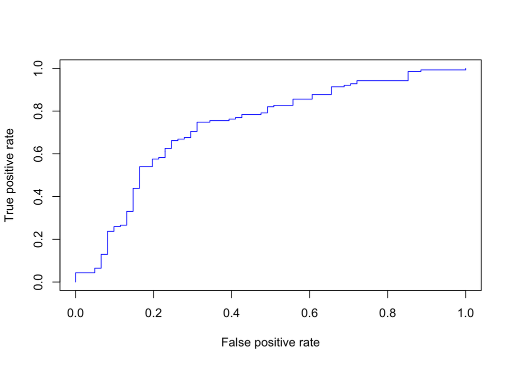

Above what you see is a plot shows how my ligistic regression model permorms in terms of AUC-ROC. Next we will put the same data in a decision tree.

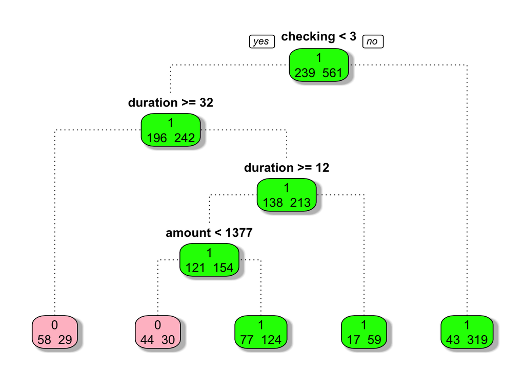

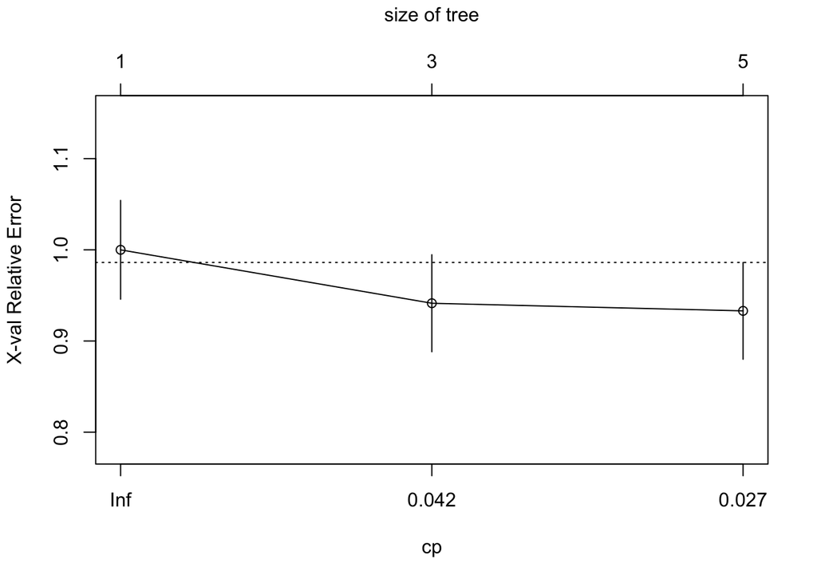

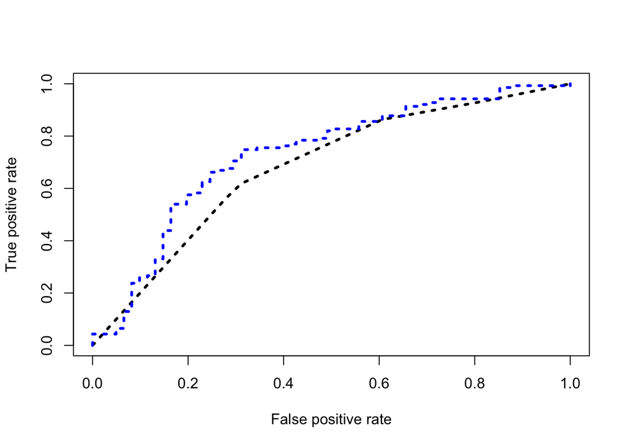

## Model comparison business insights

The two models perform in a similar fashion. However, the logistic regression has a slightly higher AUC ROC than my decision tree. What is more, it looks that the variables that the tree selected and the most important variables from my logistic regression are the same/similar. I think it would be beneficial to test this using stratified data. and maybe the models would perform better.